# Project Title – Predicting Drug Mechanism of Action using Chemical Fingerprinting

## Problem Definition

Problem Definition: The goal of this project is to develop a QSAR (Quantitative Structure-Activity Relationship) model to predict the mechanisms of action (MOA) and biological targets of drugs based on their molecular structures. This classification problem aims to leverage PubChem chemical fingerprints and data from the Broad Drug Repurposing Hub to achieve accurate predictions.

```python
# Set Working Directory
#import os
#os.chdir('C:/Users/Lenovo/OneDrive/Documents/CMD 4200/Phenotypic Modeling')

# Imports

import matplotlib.pyplot as plt
from matplotlib import colormaps

import random
import pandas as pd
import numpy as np
import seaborn as sns

from sklearn.model_selection import train_test_split
from sklearn.cluster import KMeans
from sklearn.decomposition import PCA
from sklearn.preprocessing import (label_binarize, LabelEncoder)
from sklearn import svm
from sklearn.multiclass import OneVsRestClassifier
from sklearn.metrics import (
    auc, roc_auc_score, roc_curve, confusion_matrix, classification_report
)
from sklearn.neighbors import KNeighborsClassifier
from sklearn.model_selection import KFold

from sklearn.utils import resample

# Custom function for extracting pubchem fingerprints
from getFPfromCID import getFPfromCID
```

## Data Source

The primary data source for this project is the [Broad Drug Repurposing Hub](https://repo-hub.broadinstitute.org/repurposing) dataset, a curated collection of FDA-approved drugs and experimental compounds verified for chemical structure, biological mechanisms, and regulatory status. By testing these drugs against various disease models, researchers aim to discover new therapeutic uses for existing drugs and gain insights into disease mechanisms. This dataset will provide the target variables for the classification model.

## Machine Learning Algorithm

I will use Support Vector Machine (SVM) classification modelling to predict drug and mechanisms of action using PubChem fingerprints.

Mechanisms of action will be explored at two levels of granuality. First, i will explore general mechanism of action (MOA) as the target variable. Mechanisms of action with less then 20 obserations will be excluded from the analysis. The top mechnaisms of action by observation counts are shown in Table 1.

Second, I will apply the same modeling techniques to predict the gene targets of the drugs. I will include genes with at least 20 observation and will apply oversamping if necessary to balance the number of observations in each class.

## Metric of Assessment

This study is intended to align with [A gene essentiality signature enables predicting the mechanism of action of drugs](https://www.biorxiv.org/content/10.1101/2022.11.07.514541v2.full). In this publications, the authors used a novel gene essentiality signatures to predict drug targets by comparing their performance to gene expression signatures and chemical structure fingerprints (MACCS and ECFP). Using a method developed in the DREAM competition, similar to k nearest neighbors the authors were able to achieve AUROC (Area Under the Receiver Operating Characteristic Curve) values between 0.47 and 0.43 using chemical fingerprints. I will use these values as the benchmark to compare my model.

### Mechanism of Action Data

Mechanisms of Action with at least 20 observations were included.

```python
# This file serves key to convert PubChem CID identifiers to their equivalent Broad ID. Current and depracated IDs are merged to increase matches.
compounds = pd.read_table('https://storage.googleapis.com/cdot-general-storage/repurposing_samples_20240610.txt', skiprows = 9).dropna(subset = 'pubchem_cid')
compounds['pubchem_cid'] = compounds['pubchem_cid'].astype(int)

# This file contains information about mechanism of action and targets
treatment = pd.read_table('https://s3.amazonaws.com/data.clue.io/repurposing/downloads/repurposing_drugs_20200324.txt', skiprows = 9)

# Inner merge to filte for only matching
BroadChems = pd.merge(compounds, treatment, on = 'pert_iname', how = 'inner').drop_duplicates(subset = 'pubchem_cid')
BroadChems.columns = BroadChems.columns.str.upper()
BroadChems.index = BroadChems.PUBCHEM_CID

# Mechaism of action with more than 20 observations
topMoa = pd.DataFrame({'COUNT' : BroadChems.groupby(['MOA']).size().sort_values(ascending = False)})
topMoa = topMoa[topMoa.COUNT>20]
topMoa.head()
```

| MOA | COUNT |
| --- | --- |
| adrenergic receptor antagonist | 101 |
| cyclooxygenase inhibitor | 100 |
| bacterial cell wall synthesis inhibitor | 84 |
| adrenergic receptor agonist | 83 |
| glutamate receptor antagonist | 75 |

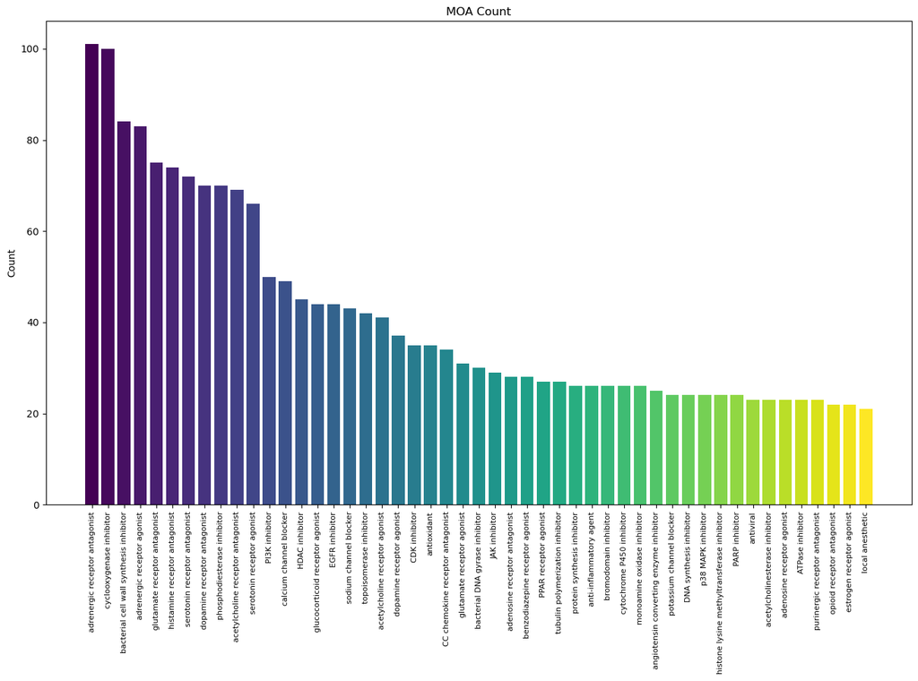

```python
cmap = colormaps['viridis']

# colormap for MOA Data
col1 = cmap(np.linspace(0, 1, len(set(topMoa.index))))

# Target Variables by Count

plt.figure(figsize=(16,9))
plt.bar(topMoa.index, topMoa.COUNT, color = col1)

plt.ylabel("Count")
plt.title("MOA Count")
plt.tick_params(axis='x', labelrotation=90, labelsize = 8)
plt.show()
```

### Fingerprints

Below is a subset of the fingerprints used to predict MOA

```python
#fingerprints = getFPfromCID(compounds.pubchem_cid.unique())
#fingerprints.to_csv('fingerprints.csv')

# Fingerprints were save to csv to reduce load on Pubchem API, but can be obtained with getFPfromCID fucntion
fingerprints = pd.read_csv('fingerprints2.csv', index_col = 0)
fingerprints = fingerprints.loc[:, fingerprints.var()>0] # Remove zero variance predictors
fingerprints.head()
```

|  | >= 4 H | >= 8 H | >= 16 H | >= 32 H | >= 1 B | >= 2 C | >= 4 C | >= 8 C | >= 16 C | >= 32 C | ... | SC1CC(N)CC1 | NC1CC(N)CC1 | CC1C(C)CCC1 | CC1C(O)CCC1 | CC1C(S)CCC1 | CC1C(N)CCC1 | CC1C(Br)CCC1 | OC1C(O)CCC1 | OC1C(N)CCC1 | NC1C(N)CCC1 |
| --- | --- | --- | --- | --- | --- | --- | --- | --- | --- | --- | --- | --- | --- | --- | --- | --- | --- | --- | --- | --- | --- |
| 6005 | 1 | 1 | 1 | 0 | 0 | 1 | 1 | 1 | 1 | 0 | ... | 0 | 0 | 0 | 0 | 0 | 0 | 0 | 0 | 0 | 0 |
| 448055 | 1 | 1 | 1 | 0 | 0 | 1 | 1 | 1 | 1 | 0 | ... | 0 | 0 | 0 | 0 | 0 | 0 | 0 | 0 | 0 | 0 |
| 6918881 | 1 | 1 | 0 | 0 | 0 | 1 | 1 | 1 | 0 | 0 | ... | 0 | 0 | 0 | 0 | 0 | 0 | 0 | 0 | 0 | 0 |
| 158758 | 1 | 1 | 1 | 0 | 0 | 1 | 1 | 1 | 1 | 0 | ... | 0 | 0 | 0 | 0 | 0 | 0 | 0 | 0 | 0 | 0 |
| 163829 | 1 | 1 | 1 | 1 | 0 | 1 | 1 | 1 | 1 | 1 | ... | 0 | 0 | 0 | 0 | 0 | 0 | 0 | 0 | 0 | 0 |

5 rows × 695 columns

### Split Data into Training and Testing Sets

```python
# combine fingerprint data with MOA Data
fpData = BroadChems.join(fingerprints, how = 'inner').drop_duplicates(subset = 'PUBCHEM_CID')

# Filter data to inclucde MOAs with 20 or more observations and include only fingerprints as predictors
modelData = fpData.loc[fpData.MOA.isin(topMoa.index), fpData.columns.isin(fingerprints.columns)]

# include only MOAs wit 20 or more observations
modelTarget = fpData.MOA[fpData.MOA.isin(topMoa.index)]

# split the model into training and testing set
X_train, X_test, y_train, y_test = train_test_split(modelData, modelTarget, test_size=0.3)
X_train.head()
```

|  | >= 4 H | >= 8 H | >= 16 H | >= 32 H | >= 1 B | >= 2 C | >= 4 C | >= 8 C | >= 16 C | >= 32 C | ... | SC1CC(N)CC1 | NC1CC(N)CC1 | CC1C(C)CCC1 | CC1C(O)CCC1 | CC1C(S)CCC1 | CC1C(N)CCC1 | CC1C(Br)CCC1 | OC1C(O)CCC1 | OC1C(N)CCC1 | NC1C(N)CCC1 |
| --- | --- | --- | --- | --- | --- | --- | --- | --- | --- | --- | --- | --- | --- | --- | --- | --- | --- | --- | --- | --- | --- |
| 11581936 | 1 | 1 | 1 | 0 | 0 | 1 | 1 | 1 | 1 | 0 | ... | 0 | 0 | 0 | 0 | 0 | 0 | 0 | 0 | 0 | 0 |
| 19103 | 1 | 0 | 0 | 0 | 0 | 1 | 1 | 1 | 0 | 0 | ... | 0 | 0 | 0 | 0 | 0 | 0 | 0 | 0 | 0 | 0 |
| 50878566 | 1 | 1 | 1 | 0 | 0 | 1 | 1 | 1 | 1 | 0 | ... | 0 | 0 | 0 | 0 | 0 | 0 | 0 | 0 | 0 | 0 |
| 5497186 | 1 | 1 | 1 | 0 | 0 | 1 | 1 | 1 | 1 | 0 | ... | 0 | 0 | 0 | 0 | 0 | 0 | 0 | 0 | 0 | 0 |
| 68374 | 1 | 0 | 0 | 0 | 0 | 1 | 1 | 0 | 0 | 0 | ... | 0 | 0 | 0 | 0 | 0 | 0 | 0 | 0 | 0 | 0 |

5 rows × 695 columns

### Unsupervised Clustering

Predicters were reduced to two principle components and colored by their unsupervised cluster. The color of the labels are matched by the mechanism of action.

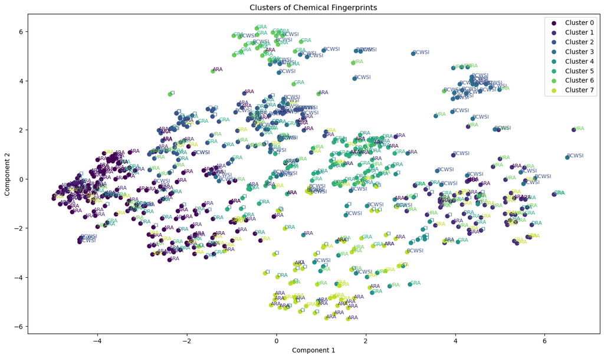

```python
# so that the graph isn't so clustered i only included 8 MOAs
plotData =  fpData.loc[fpData.MOA.isin(topMoa.index[0:8]), fpData.columns.isin(fingerprints.columns)]
plotTarget = fpData.MOA[fpData.MOA.isin(topMoa.index[0:8])]

# create name abbreviations from the caplitalized first letter of each MOA
abbr={}
for i, v in  enumerate(plotTarget):
    abbr[v] = "".join(list(map(lambda x: x[0].upper(), v.split(" "))))

# cluster with the number of cluster set to the number of MOAs
kmeans = KMeans(n_clusters=len(np.unique(plotTarget.values)))
clusters = kmeans.fit_predict(plotData)

# reduce data to 2 principal components
pca = PCA(n_components=2)
reduced_data = pca.fit_transform(plotData)

#color map
col = cmap(np.linspace(0, 0.9, len(np.unique(clusters))))

plt.figure(figsize=(16,9))
for i in range(len(np.unique(clusters))):
    cluster_points = reduced_data[clusters == i]
    plt.scatter(reduced_data[clusters == i, 0], reduced_data[clusters == i, 1], label=f'Cluster {i}', color = col[i]) #set color based on cluster

    for j, point in enumerate(cluster_points):
        idx = np.where((reduced_data == point).all(axis=1))[0][0]
        plt.annotate(abbr[plotTarget.values[idx]], (point[0], point[1]), fontsize =8, \
                     color = col[np.where(np.unique(plotTarget.values) == plotTarget.values[idx])[0]]) # set color based on class

plt.title('Clusters of Chemical Fingerprints')
plt.xlabel('Component 1')
plt.ylabel('Component 2')
plt.legend()
plt.show()
```

```python
from IPython.display import display, Markdown
display(Markdown(f'Clustering of compounds by Chemical Fingerprints of the top 10 mechansims.  Labels correspond to the drug Mechanism of action {", ".join(list(" = ".join(i) for i in abbr.items()))}'))
```

[output not shown]

### AUROC - MOA

```python
# Binarize the training Endpoint
le = LabelEncoder()
label_train = le.fit_transform(y_train)
yInt = label_binarize(label_train, classes=range(len(topMoa)))

# binarize tesing Enpoints
label_test = le.fit_transform(y_test)
yIntTest = label_binarize(label_test, classes=range(len(topMoa)))

# Perform SVM classification and predict test set
MOAmodel = OneVsRestClassifier(svm.SVC(probability=True, random_state = 10))
MOAmodel.fit(X_train, yInt)
y_probs = MOAmodel.predict_proba(X_test)

# canculate the roc and auc following the micro-average example : https://scikit-learn.org/stable/auto_examples/model_selection/plot_roc.html
fpr = dict()
tpr = dict()
roc_auc = dict()

for i in range(len(topMoa)):
    fpr[i], tpr[i], _ = roc_curve(yIntTest[:, i], y_probs[:, i])
    roc_auc[topMoa.index[i]] = auc(fpr[i], tpr[i])


# Compute micro-average ROC curve and ROC area
fpr["micro"], tpr["micro"], _ = roc_curve(yIntTest.ravel(), y_probs.ravel())
roc_auc["micro"] = auc(fpr["micro"], tpr["micro"])

pd.DataFrame({'auroc' : roc_auc}).sort_values(by = 'auroc', ascending = False).head()
```

|  | auroc |
| --- | --- |
| topoisomerase inhibitor | 1.000000 |
| protein synthesis inhibitor | 0.999334 |
| antioxidant | 0.986707 |
| CC chemokine receptor antagonist | 0.985414 |
| glucocorticoid receptor agonist | 0.983333 |

### ROC Curves - MOA

AUROC for each target class and the composite micro-average.

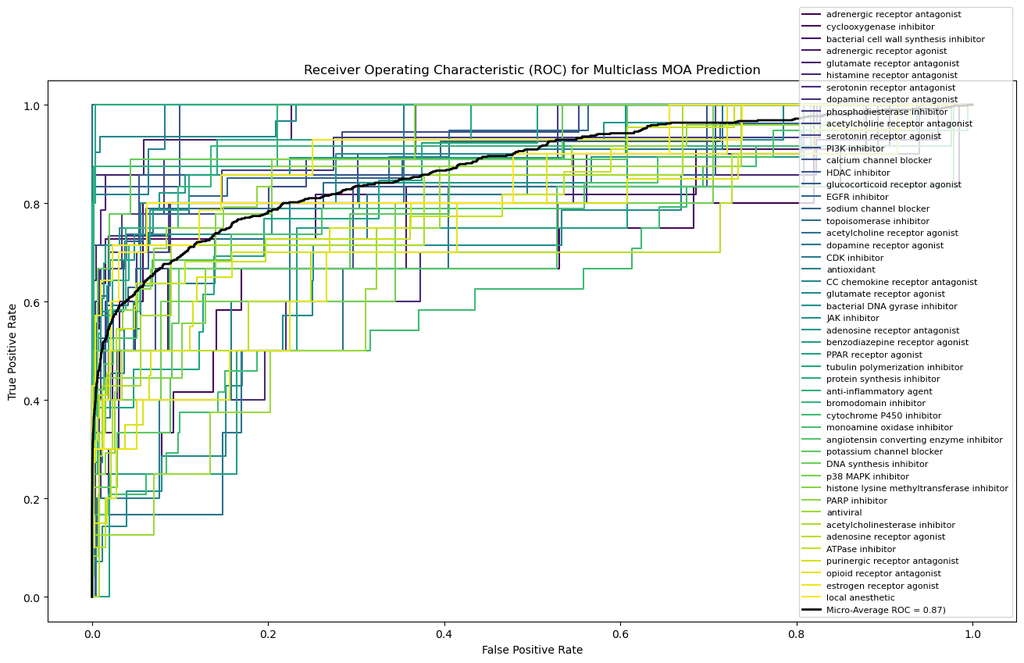

```python
# Plot ROC curve for each class and the micro-average ROC curve
cmap = colormaps['viridis']
plt.figure(figsize = (16,9))
colors = cmap(np.linspace(0, 1, len(topMoa)))

for i in range(len(topMoa)):
    plt.plot(fpr[i], tpr[i], color=colors[i],
             label=topMoa.index[i])

plt.plot(fpr["micro"], tpr["micro"], color='black', linewidth=2,
         label=f'Micro-Average ROC = {roc_auc["micro"]:0.2f})')


plt.xlabel('False Positive Rate')
plt.ylabel('True Positive Rate')
plt.title('Receiver Operating Characteristic (ROC) for Multiclass MOA Prediction')
plt.legend(loc="lower right", fontsize = 8)
plt.show()
```

### Confusion Matrix - MOA

Confusion matrix of the expected versus observed results. Predicted class was determined by the highest probablity MOA

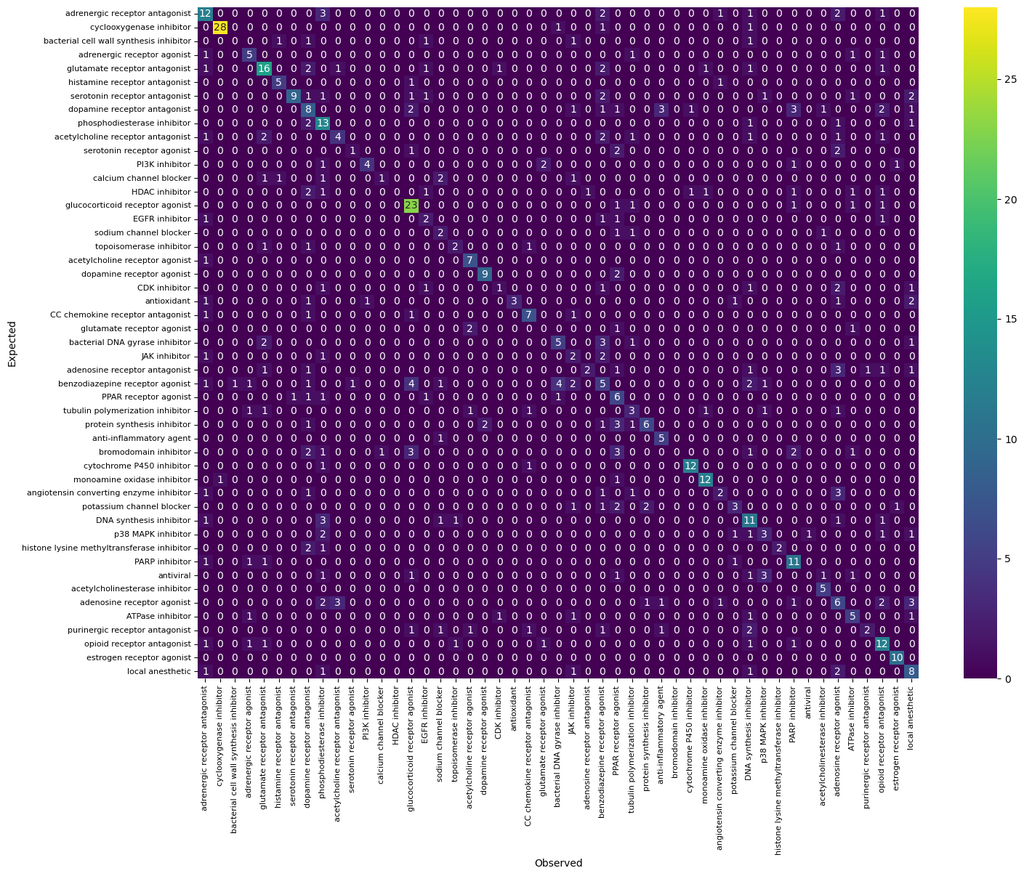

```python
#{topMoa.index[label_test[x]]
confidence = pd.DataFrame({'actual' : topMoa.index[label_test].values,
                           'highest_prop': list(map(lambda x: topMoa.index[np.where(x == x.max())][0], y_probs)), # calculate higets prob class
                            'prop_actual' : list(map(lambda x: y_probs[x][label_test[x]], np.arange(len(y_probs)))) #calculate the prob of true class
                          })


# Conflusion Matrix
conf_matrix = confusion_matrix(confidence.actual, confidence.highest_prop)
confusion_df = pd.DataFrame(conf_matrix, index = topMoa.index, columns = topMoa.index)
fig, ax = plt.subplots(figsize=(16,12))
axes = sns.heatmap(confusion_df, annot = True, cmap = 'viridis')

ax.set_xticklabels(ax.get_xticklabels(), fontsize=8)
ax.set_yticklabels(ax.get_yticklabels(), fontsize=8)
ax.set_xlabel('Observed')
ax.set_ylabel('Expected')
```

### Classification Report - MOA

```python
#MOA Classification Report

print(f"Classification Report:\n{classification_report(confidence.actual, confidence.highest_prop)}")
```

```
Classification Report:
                                            precision    recall  f1-score   support

                          ATPase inhibitor       0.46      0.55      0.50        22
          CC chemokine receptor antagonist       0.97      0.90      0.93        31
                             CDK inhibitor       0.00      0.00      0.00         5
                   DNA synthesis inhibitor       0.50      0.56      0.53         9
                            EGFR inhibitor       0.62      0.59      0.60        27
                            HDAC inhibitor       0.71      0.71      0.71         7
                             JAK inhibitor       0.90      0.47      0.62        19
                            PARP inhibitor       0.29      0.33      0.31        24
                            PI3K inhibitor       0.37      0.72      0.49        18
                     PPAR receptor agonist       0.50      0.31      0.38        13
            acetylcholine receptor agonist       0.50      0.17      0.25         6
         acetylcholine receptor antagonist       0.80      0.44      0.57         9
            acetylcholinesterase inhibitor       0.50      0.14      0.22         7
                adenosine receptor agonist       0.00      0.00      0.00        10
             adenosine receptor antagonist       0.61      0.82      0.70        28
               adrenergic receptor agonist       0.25      0.33      0.29         6
            adrenergic receptor antagonist       0.25      0.40      0.31         5
   angiotensin converting enzyme inhibitor       0.50      0.33      0.40         6
                   anti-inflammatory agent       0.64      0.88      0.74         8
                               antioxidant       0.82      0.82      0.82        11
                                 antiviral       0.33      0.12      0.18         8
            bacterial DNA gyrase inhibitor       1.00      0.30      0.46        10
   bacterial cell wall synthesis inhibitor       0.64      0.64      0.64        11
           benzodiazepine receptor agonist       0.00      0.00      0.00         4
                     bromodomain inhibitor       0.45      0.42      0.43        12
                   calcium channel blocker       0.18      0.33      0.24         6
                  cyclooxygenase inhibitor       0.67      0.17      0.27        12
                 cytochrome P450 inhibitor       0.19      0.21      0.20        24
                 dopamine receptor agonist       0.23      0.55      0.32        11
              dopamine receptor antagonist       0.30      0.30      0.30        10
                 estrogen receptor agonist       0.67      0.43      0.52        14
           glucocorticoid receptor agonist       0.50      0.83      0.62         6
                glutamate receptor agonist       0.00      0.00      0.00        14
             glutamate receptor antagonist       0.86      0.86      0.86        14
             histamine receptor antagonist       0.80      0.86      0.83        14
histone lysine methyltransferase inhibitor       0.40      0.22      0.29         9
                          local anesthetic       0.50      0.30      0.38        10
               monoamine oxidase inhibitor       0.38      0.58      0.46        19
                opioid receptor antagonist       0.33      0.30      0.32        10
                        p38 MAPK inhibitor       1.00      0.40      0.57         5
               phosphodiesterase inhibitor       0.52      0.73      0.61        15
                 potassium channel blocker       0.00      0.00      0.00         9
               protein synthesis inhibitor       0.62      1.00      0.77         5
            purinergic receptor antagonist       0.23      0.30      0.26        20
                serotonin receptor agonist       0.42      0.50      0.45        10
             serotonin receptor antagonist       0.67      0.20      0.31        10
                    sodium channel blocker       0.46      0.63      0.53        19
                   topoisomerase inhibitor       0.83      1.00      0.91        10
          tubulin polymerization inhibitor       0.36      0.57      0.44        14

                                  accuracy                           0.50       606
                                 macro avg       0.48      0.45      0.44       606
                              weighted avg       0.51      0.50      0.48       606
```

## Direct Targets

The same method was applied to predict protein targets.

### Direct Target Data

Protein targets with at least 20 observations were included in the analysis.

```python
geneData = fpData.copy()

# for cmompound with multiple targets, split by seperator and expand
geneData['TARGET'] = geneData['TARGET'].str.split('|')
geneData = geneData.explode('TARGET').dropna(subset = 'TARGET')

# Select targets with more than 20 observations
commonTargets = geneData.groupby('TARGET').size()
commonTargets = pd.DataFrame({'COUNT': commonTargets[commonTargets>20]}).sort_values('COUNT', ascending=False)

# Include only targets with 20 values
geneModel = geneData.loc[geneData.TARGET.isin(commonTargets.index), fingerprints.columns]
geneTargets = geneData.TARGET[geneData.TARGET.isin(commonTargets.index)]

commonTargets.head()
```

| TARGET | COUNT |
| --- | --- |
| HTR2A | 132 |
| DRD2 | 124 |
| HTR1A | 119 |
| ADRA1A | 97 |
| HRH1 | 96 |

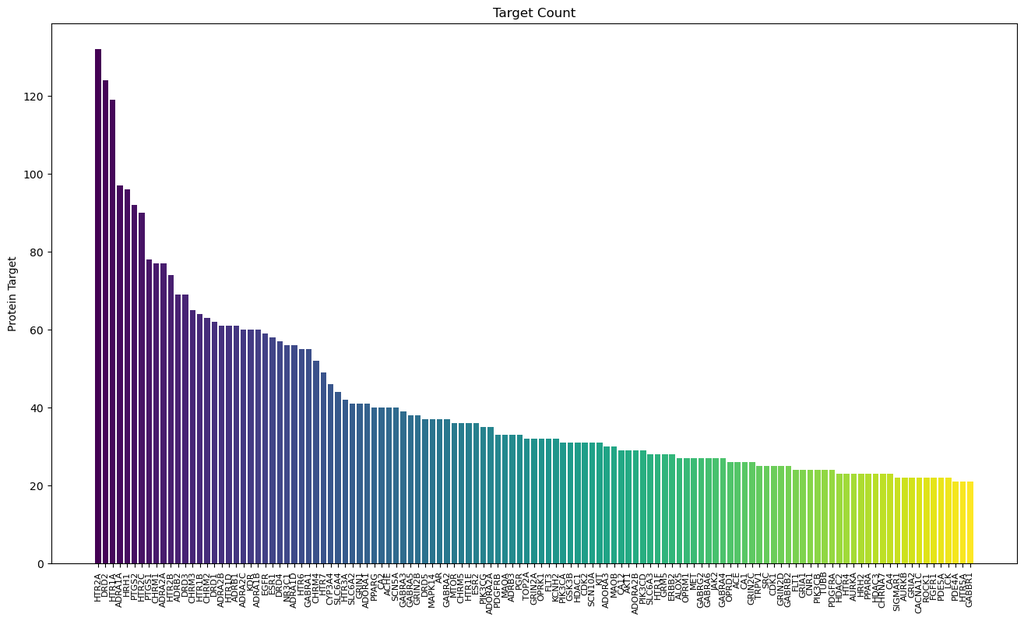

```python
# Colormap for top target counts
col2 = cmap(np.linspace(0, 1, len(commonTargets.index)))
plt.figure(figsize=(16,9))
plt.bar(commonTargets.index, commonTargets.COUNT, color = col2)

plt.ylabel("Count")
plt.ylabel("Protein Target")
plt.title("Target Count")
plt.tick_params(axis='x', labelrotation=90, labelsize = 8)
```

### AUROC - Targets

```python
# split data
X_train, X_test, y_train, y_test = train_test_split(geneModel, geneTargets, test_size=0.3)
X_train.head()
# Binarize the training Endpoint

le = LabelEncoder()
label_train = le.fit_transform(y_train)
yInt = label_binarize(label_train, classes=range(len(commonTargets)))  # Adjust the number of classes as needed

# Binarize the testing Endpoint

label_test = le.fit_transform(y_test)
yIntTest = label_binarize(label_test, classes=range(len(commonTargets)))

# SVM Classifier
geneModel = OneVsRestClassifier(svm.SVC(probability=True, random_state=10))
geneModel.fit(X_train, yInt)

y_probs = geneModel.predict_proba(X_test)

# canculate the roc and auc following the micro-average example : https://scikit-learn.org/stable/auto_examples/model_selection/plot_roc.html

fpr = dict()
tpr = dict()
roc_auc = dict()
for i in range(len(commonTargets)):
    fpr[i], tpr[i], _ = roc_curve(yIntTest[:, i], y_probs[:, i])
    roc_auc[commonTargets.index[i]] = auc(fpr[i], tpr[i])


# Compute micro-average ROC curve and ROC area
fpr["micro"], tpr["micro"], _ = roc_curve(yIntTest.ravel(), y_probs.ravel())
roc_auc["micro"] = auc(fpr["micro"], tpr["micro"])

pd.DataFrame({'auroc' : roc_auc}).sort_values(by = 'auroc', ascending = False)
```

|  | auroc |
| --- | --- |
| HTR2A | 0.999865 |
| CDK1 | 0.999127 |
| GABRA5 | 0.960942 |
| ADRA2C | 0.960929 |
| KDR | 0.930020 |
| ... | ... |
| ALOX5 | 0.500000 |
| HTR4 | 0.487830 |
| ESR2 | 0.423207 |
| CHRM2 | 0.307215 |
| AKT1 | 0.244029 |

122 rows × 1 columns

### ROC Curves - Targets

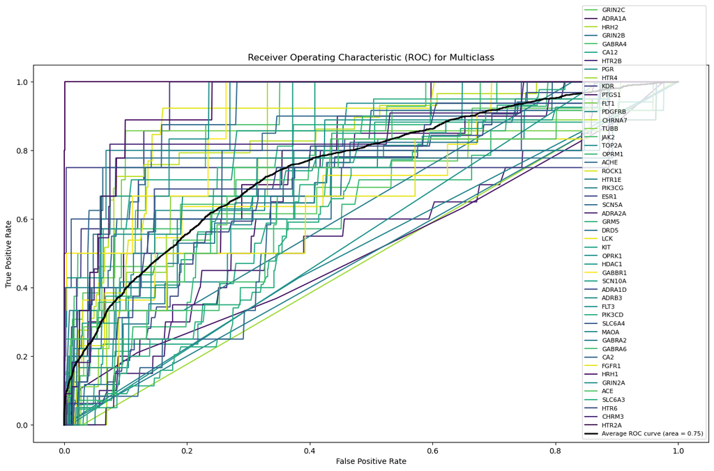

```python
# Plot ROC curve for each class and the micro-average ROC curve
cmap = colormaps['viridis']
plt.figure(figsize = (16,9))
colors = cmap(np.linspace(0, 1, len(commonTargets)))


for i in random.sample(range(len(commonTargets)), 50):
    plt.plot(fpr[i], tpr[i], color=colors[i],
             label=commonTargets.index[i])

plt.plot(fpr["micro"], tpr["micro"], color='black', linewidth=2, label='Average ROC curve (area = {0:0.2f})'.format(roc_auc["micro"]))


plt.xlabel('False Positive Rate')
plt.ylabel('True Positive Rate')
plt.title('Receiver Operating Characteristic (ROC) for Multiclass')
plt.legend(loc="lower right", fontsize = 8)
plt.show()
```

### Classification Report - Targets

```python
print(f"Classification Report:\n{classification_report(confidence.actual, confidence.highest_prop)}")
```

[output not shown]

### Fibraurea tinctoria Predictions - Data

The resulting models were applied to compounds found in the extracts of *Fibraurea tinctoria*. PubChem CID identifiers were obtained from [AID 311859](https://pubchem.ncbi.nlm.nih.gov/bioassay/311859)

```python
# exttracts from Fibraurea tinctoria
extracts = [73442,24762429,24762502,24762503,24762504,44445723,44445724,44445725,12312690,72323,72310,10358881,3823]

extractsFP = getFPfromCID(extracts)
extractsFP.head()
```

|  | >= 4 H | >= 8 H | >= 16 H | >= 32 H | >= 1 Li | >= 2 Li | >= 1 B | >= 2 B | >= 4 B | >= 2 C | ... | SC1C(S)CCC1 | SC1C(N)CCC1 | SC1C(Cl)CCC1 | SC1C(Br)CCC1 | NC1C(N)CCC1 | NC1C(Cl)CC1 | NC1C(Br)CCC1 | ClC1C(Cl)CCC1 | ClC1C(Br)CCC1 | BrC1C(Br)CCC1 |
| --- | --- | --- | --- | --- | --- | --- | --- | --- | --- | --- | --- | --- | --- | --- | --- | --- | --- | --- | --- | --- | --- |
| 73442 | 1 | 1 | 1 | 0 | 0 | 0 | 0 | 0 | 0 | 1 | ... | 0 | 0 | 0 | 0 | 0 | 0 | 0 | 0 | 0 | 0 |
| 24762429 | 1 | 1 | 1 | 0 | 0 | 0 | 0 | 0 | 0 | 1 | ... | 0 | 0 | 0 | 0 | 0 | 0 | 0 | 0 | 0 | 0 |
| 24762502 | 1 | 1 | 1 | 1 | 0 | 0 | 0 | 0 | 0 | 1 | ... | 0 | 0 | 0 | 0 | 0 | 0 | 0 | 0 | 0 | 0 |
| 24762503 | 1 | 1 | 1 | 1 | 0 | 0 | 0 | 0 | 0 | 1 | ... | 0 | 0 | 0 | 0 | 0 | 0 | 0 | 0 | 0 | 0 |
| 24762504 | 1 | 1 | 1 | 1 | 0 | 0 | 0 | 0 | 0 | 1 | ... | 0 | 0 | 0 | 0 | 0 | 0 | 0 | 0 | 0 | 0 |

5 rows × 881 columns

### Fibraurea tinctoria Predictions - MOA

```python
# probability of each MOA for each compound
MOApred = MOAmodel.predict_proba(extractsFP.loc[:, X_test.columns])
MOApredDF= pd.DataFrame(MOApred.T)
MOApredDF.index = topMoa.index
MOApredDF.columns = extracts
MOApredDF.sort_values(by = 12312690, ascending = False).head()
```

| MOA | 73442 | 24762429 | 24762502 | 24762503 | 24762504 | 44445723 | 44445724 | 44445725 | 12312690 | 72323 | 72310 | 10358881 | 3823 |
| --- | --- | --- | --- | --- | --- | --- | --- | --- | --- | --- | --- | --- | --- |
| anti-inflammatory agent | 0.001516 | 0.014334 | 0.015449 | 0.015449 | 0.007691 | 0.130778 | 0.009602 | 0.009681 | 0.385141 | 0.001508 | 0.001508 | 0.001508 | 0.002314 |
| adrenergic receptor antagonist | 0.016544 | 0.011236 | 0.025661 | 0.025661 | 0.012625 | 0.086378 | 0.010353 | 0.008133 | 0.061250 | 0.015446 | 0.015446 | 0.015446 | 0.009178 |
| benzodiazepine receptor agonist | 0.024916 | 0.053854 | 0.026136 | 0.026136 | 0.037383 | 0.029141 | 0.031536 | 0.032823 | 0.039142 | 0.026956 | 0.026956 | 0.026956 | 0.213907 |
| dopamine receptor agonist | 0.003188 | 0.003219 | 0.071606 | 0.071606 | 0.054289 | 0.130247 | 0.115800 | 0.096626 | 0.018740 | 0.011131 | 0.011131 | 0.011131 | 0.001408 |
| purinergic receptor antagonist | 0.024384 | 0.016489 | 0.008714 | 0.008714 | 0.012126 | 0.012475 | 0.015679 | 0.013380 | 0.015593 | 0.009458 | 0.009458 | 0.009458 | 0.048389 |

### Fibraurea tinctoria Predictions - Targets

```python
# probability of each Target for each compound
targetpred = geneModel.predict_proba(extractsFP.loc[:, X_test.columns])
targetpredDF= pd.DataFrame(targetpred.T)
targetpredDF.index = commonTargets.index
targetpredDF.columns = extracts
targetpredDF.sort_values(by = 12312690, ascending = False).head()
```

| TARGET | 73442 | 24762429 | 24762502 | 24762503 | 24762504 | 44445723 | 44445724 | 44445725 | 12312690 | 72323 | 72310 | 10358881 | 3823 |
| --- | --- | --- | --- | --- | --- | --- | --- | --- | --- | --- | --- | --- | --- |
| CDK1 | 0.001742 | 0.020316 | 0.027141 | 0.027141 | 0.003744 | 0.700793 | 0.017373 | 0.006734 | 0.836088 | 0.001966 | 0.001966 | 0.001966 | 0.001751 |
| ADORA3 | 0.024330 | 0.021643 | 0.021619 | 0.021619 | 0.023977 | 0.024056 | 0.020444 | 0.018631 | 0.029371 | 0.023792 | 0.023792 | 0.023792 | 0.022207 |
| HTR1F | 0.018061 | 0.021065 | 0.020623 | 0.020623 | 0.020828 | 0.019949 | 0.021080 | 0.020379 | 0.019961 | 0.018360 | 0.018360 | 0.018360 | 0.016822 |
| PIK3CD | 0.025333 | 0.022460 | 0.023043 | 0.023043 | 0.023074 | 0.019720 | 0.022116 | 0.022130 | 0.019627 | 0.025926 | 0.025926 | 0.025926 | 0.023800 |
| HTR2C | 0.027360 | 0.017585 | 0.017224 | 0.017224 | 0.018561 | 0.018568 | 0.016501 | 0.015018 | 0.019528 | 0.023046 | 0.023046 | 0.023046 | 0.019146 |

## Makisterone A

PubChem CID 12312690, Makisterone A, was identified as a potential anti-inflammatory and CDK1 modulator.